# The Gears Inside the *Steam* Engine

Amelia Pasquino

Published 16 Dec, 2022

# **0. Introduction**

Video games are a medium that has taken the world by storm over the few decades they have existed. From a niche industry in the early 1980s to one that generates on the order of $100B annually, the growth has provided a relatively new industry to inspect. Many people less familiar with the games industry would first think of home consoles such as the Xbox and PlayStation, but a significant portion of the industry lives and thrives through computer games.

The undisputed titan of the PC gaming marketplace is *Steam* a storefront and online hub established in 2003 by game development studio/publisher *Valve*. It changed the landscape of online gaming, essentially acting as the Amazon.com for PC games. Most major studios list their games to be bought and played through *Steam*, and its user profile and friend system provide a social network surrogate on top of its marketplace function.

*Steam* is host to tens of thousands of games and millions of users, which means, as no surprise to anyone who's aware that this is a data analysis document, there is plenty of information! In this tutorial, we'll be taking a look at trends in game popularity and examining what keeps the platform ticking.

```python
# importing libraries
import pandas as pd
import numpy as np
import matplotlib.pyplot as plt
import scipy.stats as scs
import seaborn as sb
import warnings
warnings.filterwarnings('ignore')
```

# **1. Data Collection**

In order to do any analysis of data, we need data. For the purposes of this tutorial, data was retrieved from two [Kaggle](https://www.kaggle.com/) repositories: game data can be found [here](https://www.kaggle.com/datasets/nikdavis/steam-store-games), and user data can be found [here](https://www.kaggle.com/datasets/tamber/steam-video-games). The first repository consists of six documents, of which this tutorial will be discussing two in addition to the document from the second repository. These data are pulled from the APIs of both [Steam](https://store.steampowered.com/) and [SteamSpy](https://steamspy.com/) circa 2019.

## **1a. Games**

```python
games = pd.read_csv('data/steam.csv')
games.head()
```

|  | appid | name | release_date | english | developer | publisher | platforms | required_age | categories | genres | steamspy_tags | achievements | positive_ratings | negative_ratings | average_playtime | median_playtime | owners | price |
| --- | --- | --- | --- | --- | --- | --- | --- | --- | --- | --- | --- | --- | --- | --- | --- | --- | --- | --- |
| 0 | 10 | Counter-Strike | 2000-11-01 | 1 | Valve | Valve | windows;mac;linux | 0 | Multi-player;Online Multi-Player;Local Multi-P... | Action | Action;FPS;Multiplayer | 0 | 124534 | 3339 | 17612 | 317 | 10000000-20000000 | 7.19 |
| 1 | 20 | Team Fortress Classic | 1999-04-01 | 1 | Valve | Valve | windows;mac;linux | 0 | Multi-player;Online Multi-Player;Local Multi-P... | Action | Action;FPS;Multiplayer | 0 | 3318 | 633 | 277 | 62 | 5000000-10000000 | 3.99 |
| 2 | 30 | Day of Defeat | 2003-05-01 | 1 | Valve | Valve | windows;mac;linux | 0 | Multi-player;Valve Anti-Cheat enabled | Action | FPS;World War II;Multiplayer | 0 | 3416 | 398 | 187 | 34 | 5000000-10000000 | 3.99 |
| 3 | 40 | Deathmatch Classic | 2001-06-01 | 1 | Valve | Valve | windows;mac;linux | 0 | Multi-player;Online Multi-Player;Local Multi-P... | Action | Action;FPS;Multiplayer | 0 | 1273 | 267 | 258 | 184 | 5000000-10000000 | 3.99 |
| 4 | 50 | Half-Life: Opposing Force | 1999-11-01 | 1 | Gearbox Software | Valve | windows;mac;linux | 0 | Single-player;Multi-player;Valve Anti-Cheat en... | Action | FPS;Action;Sci-fi | 0 | 5250 | 288 | 624 | 415 | 5000000-10000000 | 3.99 |

Let's make sure our data doesn't have any duplicates. This is rather easy to do: we want one row for every game ID.

```python
print(len(games['appid']))
print(len(games['appid'].unique()))
```

```
27075
27075
```

Looks good. Diving into the `games` table, we have 18 columns. These columns are described below.

1. `AppID` - unique identifier
2. `Name` - game's name, as displayed in the Steam store
3. `Release Date` - date game was made available
4. `English` - whether the game's primary release language is English
5. `Developer` - company that created the game
6. `Publisher` - company that published the game
7. `Platforms` - list of operating systems on which the game is playable
8. `Required Age` - age restriction for players
9. `Categories` - list of Steam-defined category descriptors
10. `Genres` - list of Steam-defined game genre(s)
11. `SteamSpy Tags` - list of user-driven category descriptors
12. `Achievements` - number of in-game achievements
13. `Positive Ratings` - number of positive user reviews
14. `Negative Ratings` - number of negative user reviews
15. `Average Playtime` - average time spent playing per owner (min)
16. `Median Playtime` - median time spent playing per owner (min)
17. `Owners` - approximate user count
18. `Price` - cost on Steam store

## **1b. Tags**

```python
tags = pd.read_csv('data/steamspy_tag_data.csv')

# scale each tag to be within [0,1]
for col in tags:
  if col != 'appid':
    tags[col] = tags[col] / tags[col].max()

tags.head()
```

|  | appid | 1980s | 1990s | 2.5d | 2d | 2d_fighter | 360_video | 3d | 3d_platformer | 3d_vision | ... | warhammer_40k | web_publishing | werewolves | western | word_game | world_war_i | world_war_ii | wrestling | zombies | e_sports |
| --- | --- | --- | --- | --- | --- | --- | --- | --- | --- | --- | --- | --- | --- | --- | --- | --- | --- | --- | --- | --- | --- |
| 0 | 10 | 0.150943 | 1.000000 | 0.0 | 0.0 | 0.0 | 0.0 | 0.0 | 0.0 | 0.0 | ... | 0.0 | 0.0 | 0.0 | 0.0 | 0.0 | 0.000000 | 0.000000 | 0.0 | 0.0 | 0.065429 |
| 1 | 20 | 0.000000 | 0.125887 | 0.0 | 0.0 | 0.0 | 0.0 | 0.0 | 0.0 | 0.0 | ... | 0.0 | 0.0 | 0.0 | 0.0 | 0.0 | 0.000000 | 0.000000 | 0.0 | 0.0 | 0.000000 |
| 2 | 30 | 0.000000 | 0.000000 | 0.0 | 0.0 | 0.0 | 0.0 | 0.0 | 0.0 | 0.0 | ... | 0.0 | 0.0 | 0.0 | 0.0 | 0.0 | 0.006702 | 0.045235 | 0.0 | 0.0 | 0.000000 |
| 3 | 40 | 0.000000 | 0.000000 | 0.0 | 0.0 | 0.0 | 0.0 | 0.0 | 0.0 | 0.0 | ... | 0.0 | 0.0 | 0.0 | 0.0 | 0.0 | 0.000000 | 0.000000 | 0.0 | 0.0 | 0.000000 |
| 4 | 50 | 0.000000 | 0.136525 | 0.0 | 0.0 | 0.0 | 0.0 | 0.0 | 0.0 | 0.0 | ... | 0.0 | 0.0 | 0.0 | 0.0 | 0.0 | 0.000000 | 0.000000 | 0.0 | 0.0 | 0.000000 |

5 rows × 372 columns

The `tags` table is an encoding of user votes for each tag in each game. This is an expansion of the lists found in the `steamspy_tags` column of the `games` table. There are 371 unique tags.

## **1c. Users**

```python
users = pd.read_csv('data/steam_user_data.csv',
                    names = ['userid', 'name', 'activity', 'value', 'zero'])
users.head()
```

|  | userid | name | activity | value | zero |
| --- | --- | --- | --- | --- | --- |
| 0 | 151603712 | The Elder Scrolls V Skyrim | purchase | 1.0 | 0 |
| 1 | 151603712 | The Elder Scrolls V Skyrim | play | 273.0 | 0 |
| 2 | 151603712 | Fallout 4 | purchase | 1.0 | 0 |
| 3 | 151603712 | Fallout 4 | play | 87.0 | 0 |
| 4 | 151603712 | Spore | purchase | 1.0 | 0 |

This data is a mixed back of activities: "purchase" which records a user buying a game, and "play" which records the user playing it. In "purchase" rows, `value` is always 1, and in "play" rows, `value` indicates the number of hours played. Since these are separate and distinct pieces of data, we'll split them. And while we're at it, we'll get rid of the columns that are now useless.

```python
# strip dataframe of "purchase" rows
playtime = users[users['activity'] == 'play']

# keep the important things and reset indexing
playtime.reset_index(inplace=True)
playtime.drop(columns=['index','activity','zero'], inplace=True)
playtime.head()
```

|  | userid | name | value |
| --- | --- | --- | --- |
| 0 | 151603712 | The Elder Scrolls V Skyrim | 273.0 |
| 1 | 151603712 | Fallout 4 | 87.0 |
| 2 | 151603712 | Spore | 14.9 |
| 3 | 151603712 | Fallout New Vegas | 12.1 |
| 4 | 151603712 | Left 4 Dead 2 | 8.9 |

```python
# the other way around
purchases = users[users['activity'] == 'purchase']
purchases.reset_index(inplace=True)
purchases.drop(columns=['index','activity','value','zero'], inplace=True)
purchases.head()
```

|  | userid | name |
| --- | --- | --- |
| 0 | 151603712 | The Elder Scrolls V Skyrim |
| 1 | 151603712 | Fallout 4 |
| 2 | 151603712 | Spore |
| 3 | 151603712 | Fallout New Vegas |
| 4 | 151603712 | Left 4 Dead 2 |

# **2. Data Management**

## **2a. Auxiliary Tables**

Now that we have our data, we want it to be in a format that is easy for our code to analyze. As text isn't particularly easy to do calculations on, we can convert some of our text fields into numerical data. To do this, we will one-hot encode a few of our columns of string lists into separate tables of binary information. The `tags` table already follows this format and has a workable form of the `steamspy_tags` column, so we will let that column alone and work on the other three dimensions we want to use: `genres`, `categories`, and `platforms`.

```python
# convert the semicolon-separated string to a list,
# and use that to find a list of all unique genres
games['genres_list'] = games['genres'].str.split(';')
genres_set = sorted(set(sum(games['genres_list'].tolist(),[])))

# create a new table with a column for each genre...
genres = games[['appid']]
for g in genres_set:
  genres[g] = games['genres'].apply(lambda x: 1 if g in x else 0)

genres.head()
```

|  | appid | Accounting | Action | Adventure | Animation & Modeling | Audio Production | Casual | Design & Illustration | Documentary | Early Access | ... | Sexual Content | Simulation | Software Training | Sports | Strategy | Tutorial | Utilities | Video Production | Violent | Web Publishing |
| --- | --- | --- | --- | --- | --- | --- | --- | --- | --- | --- | --- | --- | --- | --- | --- | --- | --- | --- | --- | --- | --- |
| 0 | 10 | 0 | 1 | 0 | 0 | 0 | 0 | 0 | 0 | 0 | ... | 0 | 0 | 0 | 0 | 0 | 0 | 0 | 0 | 0 | 0 |
| 1 | 20 | 0 | 1 | 0 | 0 | 0 | 0 | 0 | 0 | 0 | ... | 0 | 0 | 0 | 0 | 0 | 0 | 0 | 0 | 0 | 0 |
| 2 | 30 | 0 | 1 | 0 | 0 | 0 | 0 | 0 | 0 | 0 | ... | 0 | 0 | 0 | 0 | 0 | 0 | 0 | 0 | 0 | 0 |
| 3 | 40 | 0 | 1 | 0 | 0 | 0 | 0 | 0 | 0 | 0 | ... | 0 | 0 | 0 | 0 | 0 | 0 | 0 | 0 | 0 | 0 |
| 4 | 50 | 0 | 1 | 0 | 0 | 0 | 0 | 0 | 0 | 0 | ... | 0 | 0 | 0 | 0 | 0 | 0 | 0 | 0 | 0 | 0 |

5 rows × 30 columns

```python
# ...repeat the process for categories...
games['categories_list'] = games['categories'].str.split(';')
categories_set = sorted(set(sum(games['categories_list'].tolist(),[])))

categories = games[['appid']]
for c in categories_set:
  categories[c] = games['categories'].apply(lambda x: 1 if c in x else 0)

categories.head()
```

|  | appid | Captions available | Co-op | Commentary available | Cross-Platform Multiplayer | Full controller support | In-App Purchases | Includes Source SDK | Includes level editor | Local Co-op | ... | Stats | Steam Achievements | Steam Cloud | Steam Leaderboards | Steam Trading Cards | Steam Turn Notifications | Steam Workshop | SteamVR Collectibles | VR Support | Valve Anti-Cheat enabled |
| --- | --- | --- | --- | --- | --- | --- | --- | --- | --- | --- | --- | --- | --- | --- | --- | --- | --- | --- | --- | --- | --- |
| 0 | 10 | 0 | 0 | 0 | 0 | 0 | 0 | 0 | 0 | 0 | ... | 0 | 0 | 0 | 0 | 0 | 0 | 0 | 0 | 0 | 1 |
| 1 | 20 | 0 | 0 | 0 | 0 | 0 | 0 | 0 | 0 | 0 | ... | 0 | 0 | 0 | 0 | 0 | 0 | 0 | 0 | 0 | 1 |
| 2 | 30 | 0 | 0 | 0 | 0 | 0 | 0 | 0 | 0 | 0 | ... | 0 | 0 | 0 | 0 | 0 | 0 | 0 | 0 | 0 | 1 |
| 3 | 40 | 0 | 0 | 0 | 0 | 0 | 0 | 0 | 0 | 0 | ... | 0 | 0 | 0 | 0 | 0 | 0 | 0 | 0 | 0 | 1 |
| 4 | 50 | 0 | 0 | 0 | 0 | 0 | 0 | 0 | 0 | 0 | ... | 0 | 0 | 0 | 0 | 0 | 0 | 0 | 0 | 0 | 1 |

5 rows × 30 columns

```python
# ...and once more for platforms!
games['platforms_list'] = games['platforms'].str.split(';')
platforms_set = sorted(set(sum(games['platforms_list'].tolist(),[])))

platforms = games[['appid']]
for p in platforms_set:
  platforms[p] = games['platforms'].apply(lambda x: 1 if p in x else 0)

platforms.head()
```

|  | appid | linux | mac | windows |
| --- | --- | --- | --- | --- |
| 0 | 10 | 1 | 1 | 1 |
| 1 | 20 | 1 | 1 | 1 |
| 2 | 30 | 1 | 1 | 1 |
| 3 | 40 | 1 | 1 | 1 |
| 4 | 50 | 1 | 1 | 1 |

## **2b. Narrowing the View**

Now that we've got some key information encoded, we can drop the original text data from our source table, as well as the list versions of those columns. There is also the interesting case of the `owners` dimension. This would be fantastic information, if it were precise. However, these ranges are massive and not easy to work with. But that's okay! We have data from our other source we can use as a sample space instead.

With all of this in mind, let's clean up `games`.

```python
# preserve the original
games_o = games
# 2 new columns we'll make use of
games['month'] = pd.to_datetime(games['release_date']).dt.to_period('M')
games['total_ratings'] = games['positive_ratings'] + games['negative_ratings']
games['percent_approval'] = games['positive_ratings'] / games['total_ratings'] * 100

# drop the columns we don't care for
games.drop(
    ['platforms', 'categories', 'genres',
     'platforms_list', 'categories_list', 'genres_list',
     'steamspy_tags', 'owners', 'english'],
     axis=1, inplace=True)
games.head()
```

|  | appid | name | release_date | developer | publisher | required_age | achievements | positive_ratings | negative_ratings | average_playtime | median_playtime | price | month | total_ratings | percent_approval |
| --- | --- | --- | --- | --- | --- | --- | --- | --- | --- | --- | --- | --- | --- | --- | --- |
| 0 | 10 | Counter-Strike | 2000-11-01 | Valve | Valve | 0 | 0 | 124534 | 3339 | 17612 | 317 | 7.19 | 2000-11 | 127873 | 97.388815 |
| 1 | 20 | Team Fortress Classic | 1999-04-01 | Valve | Valve | 0 | 0 | 3318 | 633 | 277 | 62 | 3.99 | 1999-04 | 3951 | 83.978740 |
| 2 | 30 | Day of Defeat | 2003-05-01 | Valve | Valve | 0 | 0 | 3416 | 398 | 187 | 34 | 3.99 | 2003-05 | 3814 | 89.564761 |
| 3 | 40 | Deathmatch Classic | 2001-06-01 | Valve | Valve | 0 | 0 | 1273 | 267 | 258 | 184 | 3.99 | 2001-06 | 1540 | 82.662338 |
| 4 | 50 | Half-Life: Opposing Force | 1999-11-01 | Gearbox Software | Valve | 0 | 0 | 5250 | 288 | 624 | 415 | 3.99 | 1999-11 | 5538 | 94.799567 |

## **2c. Cleaning and Meshing**

We're almost ready to start analysis, but our user data still isn't compatible with our game and tag information. To do this, we'll add `appid` to each row in our tables. Unfortunately, our `name` fields don't match!

```python
print(games[games['name'].str.contains('Skyrim')]['name'].unique())
print(playtime[playtime['name'].str.contains('Skyrim')]['name'].unique())
```

```
['The Elder Scrolls V: Skyrim'
 'The Elder Scrolls V: Skyrim Special Edition'
 'The Elder Scrolls V: Skyrim VR']
['The Elder Scrolls V Skyrim']
```

Let's clean this up. We'll take out the messy bits to help the names line up.

```python
def clean_name(df):
  # special characters
  df['name'] = df['name'].str.replace('[\N{COPYRIGHT SIGN}\N{TRADE MARK SIGN}\N{REGISTERED SIGN}]', '')
  df['name'] = df['name'].str.replace(':', '')
  # the opposite of edition is subtraction
  df['name'] = df['name'].str.replace('- Game of the Year Edition', '')
  df['name'] = df['name'].str.replace(' Game of the Year Edition', '')
  df['name'] = df['name'].str.replace(' Game of the Year', '')
  # whitespace stragglers
  df['name'] = df['name'].str.strip()

clean_name(games)
clean_name(playtime)
clean_name(purchases)

# do you hear the people string
print(games[games['name'].str.contains('Skyrim')]['name'].unique())
print(playtime[playtime['name'].str.contains('Skyrim')]['name'].unique())
```

```
['The Elder Scrolls V Skyrim' 'The Elder Scrolls V Skyrim Special Edition'
 'The Elder Scrolls V Skyrim VR']
['The Elder Scrolls V Skyrim']
```

Now we have a match. Catching every edge case is a bit tedious to do manually, so we'll merge what we've got left and make sure we still have a decent amount of data to work with.

```python
purchases = purchases.merge(games, on=['name'], how='inner')[['userid','name','appid']]
playtime = playtime.merge(games, on=['name'], how='inner')[['userid','name','appid','value']]

print(len(purchases))
print(len(playtime))
```

```
85578
52739
```

# **3. Data Exploration and Analysis**

## **3a. Popularity**

One of the most immediate questions we can answer is: what are the most popular games? We can take purchase and playtime data and look at the top games to see what people are buying and playing, and if there are any discrepancies.

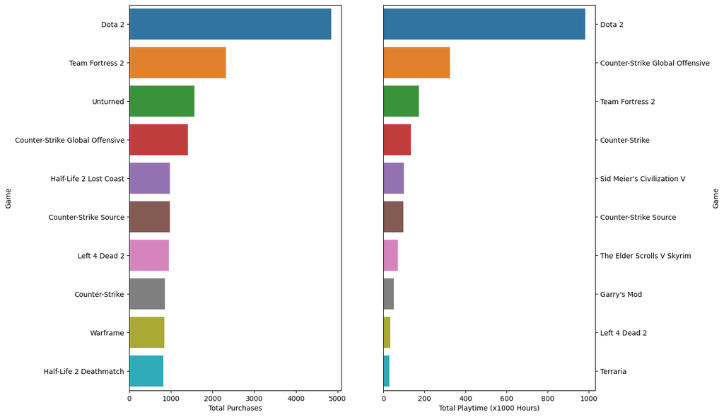

```python
n_games = 10

# top 10 games most people have
agg_purchases = purchases.groupby('name')['name'].count().sort_values(ascending=False)
agg_purchases = pd.DataFrame(
    {'name': agg_purchases.index,
     'times_purchased': agg_purchases.values})
agg_p = agg_purchases[0:n_games]

# top 10 games by playtime
agg_hours = playtime.groupby('name')['value'].sum().sort_values(ascending=False)
agg_hours = pd.DataFrame(
    {'name': agg_hours.index,
     'total_playtime': agg_hours.values / 1000})
agg_h = agg_hours[0:n_games]

# some pretty bars
fig, ax = plt.subplots(1,2,figsize=(12,n_games))
sb.barplot(data=agg_p, y='name', x='times_purchased', ax=ax[0])
ax[0].set(xlabel='Total Purchases', ylabel='Game')
sb.barplot(data=agg_h, y='name', x='total_playtime', ax=ax[1])
ax[1].set(xlabel='Total Playtime (x1000 Hours)', ylabel='Game')
ax[1].yaxis.tick_right()
ax[1].yaxis.set_label_position('right')
```

*Dota 2* seems to reign supreme in both of these categories! However, there's a lot different about these two visuals in order and content. Could the games in either category have something in common? Let's take a look at the most common tags in the games in each set.

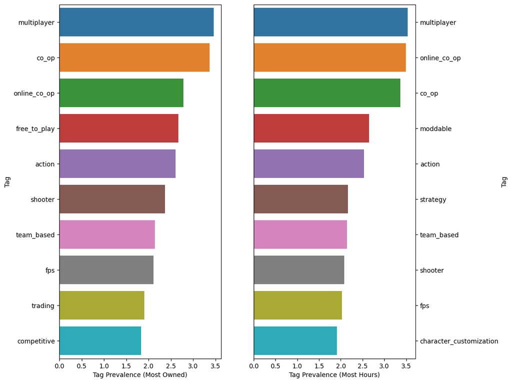

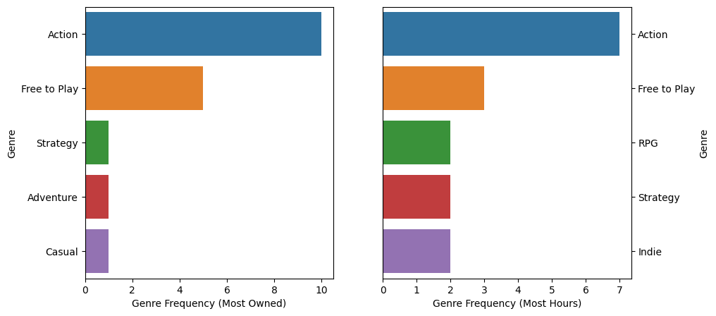

```python
n_items = 10
# retreive app ids
p_i = agg_p.merge(games, on=['name'], how='inner')[['name','appid', 'times_purchased']]
h_i = agg_h.merge(games, on=['name'], how='inner')[['name','appid','total_playtime']]

# combine with encoding
p_genres = p_i.merge(genres, on=['appid'], how='inner')
h_genres = h_i.merge(genres, on=['appid'], how='inner')
p_tags = p_i.merge(tags, on=['appid'], how='inner')
h_tags = h_i.merge(tags, on=['appid'], how='inner')

# find the ones that are the most genre
agg_pt = p_tags.drop(columns=['name','appid','times_purchased']).sum().sort_values(ascending=False)
agg_ht = h_tags.drop(columns=['name','appid','total_playtime']).sum().sort_values(ascending=False)
agg_pg = p_genres.drop(columns=['name','appid','times_purchased']).sum().sort_values(ascending=False)
agg_hg = h_genres.drop(columns=['name','appid','total_playtime']).sum().sort_values(ascending=False)

# frame 'em
agg_pt = pd.DataFrame({'name': agg_pt.index, 'freq': agg_pt.values})[0:n_items]
agg_ht = pd.DataFrame({'name': agg_ht.index, 'freq': agg_ht.values})[0:n_items]
agg_pg = pd.DataFrame({'name': agg_pg.index, 'freq': agg_pg.values})[0:int(n_items/2)]
agg_hg = pd.DataFrame({'name': agg_hg.index, 'freq': agg_hg.values})[0:int(n_items/2)]

# graph 'em
fig, ax = plt.subplots(1,2,figsize=(10,n_items))
sb.barplot(data=agg_pt, y='name', x='freq', ax=ax[0])
ax[0].set(xlabel='Tag Prevalence (Most Owned)', ylabel='Tag')
sb.barplot(data=agg_ht, y='name', x='freq', ax=ax[1])
ax[1].set(xlabel='Tag Prevalence (Most Hours)', ylabel='Tag')
ax[1].yaxis.tick_right()
ax[1].yaxis.set_label_position('right')
plt.show()

# stick 'em in a visualization
fig, ax = plt.subplots(1,2,figsize=(10,5))
sb.barplot(data=agg_pg, y='name', x='freq', ax=ax[0])
ax[0].set(xlabel='Genre Frequency (Most Owned)', ylabel='Genre')
sb.barplot(data=agg_hg, y='name', x='freq', ax=ax[1])
ax[1].set(xlabel='Genre Frequency (Most Hours)', ylabel='Genre')
ax[1].yaxis.tick_right()
ax[1].yaxis.set_label_position('right')
```

It looks like free-to-play games are the culprit here! 5 of the most owned games are free, which makes sense intuitively. Anyone can "purchase" the game and never play it, so we should expect to see this difference. According to tags, multiplayer/co-op games dominate both charts. The free-to-play tag places 4th among game ownership, but drops out of the top ten entirely for playtime. Rising to replace it are tags such as "moddable" and "character customization," perhaps showing that when given the opportunity to tailor the play experience, users tend to spend more time with the game.

## **3b. "Quality"**

As we can see with the discrepancy between ownership and playtime, just because games are being bought does not mean they're being played. With thousands of games being published each year and only a few making headlines, it makes sense that many games slip through the cracks. To evaluate what's being played, we can look at the average playtimes of games - that is, the hours played per owner.

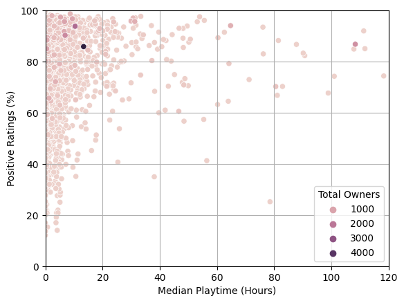

```python
# stick our tables together
# like our party is too big for this restaurant
score_df = agg_purchases.merge(agg_hours, on=['name'])
score_df['avg_playtime'] = score_df['total_playtime'] / score_df['times_purchased'] * 60
score_df.sort_values(by=['times_purchased'], ascending=True, inplace=True)
score_df.reset_index(inplace=True)
df = score_df.merge(games, on=['name'])

# hours are easier to understand
df['pt_h'] = df['median_playtime'] / 60

# pretty dots, color coded by ownership
sb.scatterplot(data=df, x='pt_h', y='percent_approval', hue='times_purchased')
plt.xlim(0,120)
plt.ylim(0,100)
plt.legend(title='Total Owners', loc='lower right')
plt.xlabel('Median Playtime (Hours)')
plt.ylabel('Positive Ratings (%)')
plt.grid()
```

Another thing of note is the density of games toward the top of the graph. Most games are liked, at least on paper. This could be the result of a tendency for proponents of a game being more likely to leave a rating than those who disliked it, or people being choosy about what they play, since Steam only allows users to rate games they've played.

## **3c. Complexity**

Another metric that can be evaluated is the complexity of a game. This is a bit more difficult to evaluate numerically, but we can develop a metric for it. For our purposes, we will use the sum of a game's tags - the more tags, the more bases a game covers, and the more complex it is.

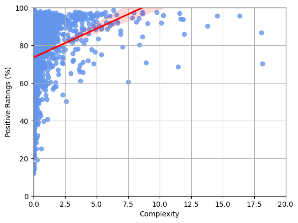

```python
# giving our games a complex(ity rating)
df_tags = tags[['appid']]
df_tags['tag_sum'] = tags.drop(columns=['appid']).sum(axis='columns')
df_complexity = df.merge(df_tags, on=['appid'])
df_complexity.head()

# regression lines, how trendy
sb.regplot(data=df_complexity, x='tag_sum', y='percent_approval',
           scatter_kws={'color': 'cornflowerblue'}, line_kws={'color': 'red'})
plt.xlim(0,20)
plt.ylim(0,100)
plt.xlabel('Complexity')
plt.ylabel('Positive Ratings (%)')
plt.grid()
```

It seems as though more complex games are more highly rated, and the only games doing poorly are those that are very simple. This is an interesting discovery, as it can open more questions about what gamers find valuable in a game. Does the addition of more game mechanics and avenues of expression equal a better game? And if this correlation truly exists, are developers striving to meet this demand for complex games? We can answer this second question by taking a look at complexity over time.

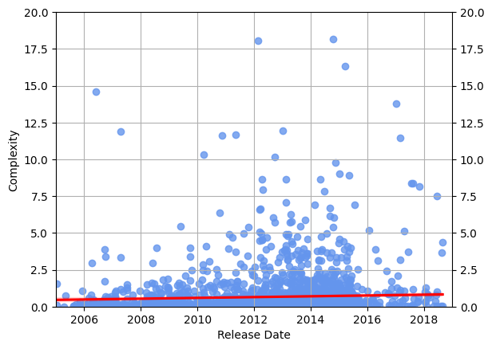

```python
# turn our release date into years (the hard way)
epoch = pd.to_datetime(df_complexity['release_date']).min()
df_complexity['days_since_epoch'] = \
  (pd.to_datetime(df_complexity['release_date']) - epoch) / np.timedelta64(1, 'Y') + epoch.year

# more dots!
sb.regplot(data=df_complexity, x='days_since_epoch', y='tag_sum',
           scatter_kws={'color': 'cornflowerblue'}, line_kws={'color': 'red'})
plt.xlim(2005,2019)
plt.ylim(0,20)
plt.xlabel('Release Date')
plt.ylabel('Complexity')
plt.tick_params(axis='y', which='both', right=True, labelright=True)
plt.grid()
```

```python
# checking our regression
m,b,r,p,err = scs.linregress(
    df_complexity['days_since_epoch'],
    df_complexity['tag_sum'])
# py r-squared
print('r-squared:', round(r**2, 4))
```

```
r-squared: 0.0024
```

This plot, while also interesting, is less convincing, and the extremely low r-squared value of the regression backs that up. It appears that game complexity, at least in terms of steam tags, is not something developers are actively striving toward.

# **4. Conclusion**

From our exploration, we have gained some interesting insights into behaviors of *Steam* users, as well as opened a few doors to more possible questions to ask about this, and associated, data. A data with more granular timeseries information could allow for a breakdown of day-to-day or month-to-month play habits of the user base. This could also allow for explorations of popularity of different tags or genres at different points in time, not just release trends. Additionally, this doesn't even begin to look at information about specific games, or even groups of games within a genre or tag.

*Steam* is a large platform with tons of available data that other researchers have pulled. This is mostly a bird's-eye view of this corner of PC gaming that aims to act as a foot in the door for anyone interested in statistics.

Data is available at the links in the introduction or [here on my github page](https://github.com/a-pasquino/a-pasquino.github.io). Thanks for reading!